# Red Wine Quality Exploration by Aseem Bansal

# Bivariate Analysis

### Talk about some of the relationships you observed in this part of the investigation. How did the feature(s) of interest vary with other features in the dataset?

#### Weak or No Relationships

These do not seem to have a direct relationship with quality

- fixed.acidity
- residual.sugar
- chlorides: The higher the quality of wine lesser the mean volatile.acidity in the wine. But the relationship did not seem too strong as the decrease wasn’t too much

#### Medium or Strong Relationships

These seem to be related with quality

- volatile.acidity: The higher the quality of wine lesser the mean volatile.acidity in the wine
- citric.acid: The higher the quality of wine higher the mean citric.acid in the wine
- free.sulfur.dioxide: Good quality wines seemed to have medium quantity of this chemical
- total.sulfur.dioxide: Good quality wines seemed to have medium quantity of this chemical
- density: For good quality wine the average density seems to decrease
- pH: For good quality wine the mean pH seems to decrease

From the chosen 4 initial variables

- volatile.acidity
- citric.acid
- free.sulfur.dioxide
- alcohol

all except `free.sulfur.dioxide` had seem to have strong relationship with quality of the wine. `sulphates` were not expected but they had strong relationships

### Did you observe any interesting relationships between the other features (not the main feature(s) of interest)?

Many variables had correlation magnitude greater than 0.5

- fixed.acidity and pH had correlation of -0.683
- citric.acid and pH had correlation of -0.542
- citric.acid and fixed.acidity had correlation of 0.672
- density and fixed.acidity had correlation of 0.668
- citric.acid and volatile.acidity had correlation of -0.552
- total.sulfur.dioxide and free.sulfur.dioxide had correlation of 0.668

But none of them were correlated to quality that strongly

- alcohol 0.476
- volatile.acidity -0.391
- sulphates 0.251
- citric.acid 0.226

Total sulphur dioxide seems to lower bounded by free sulphur dioxide

### What was the strongest relationship you found?

Looking at the graphs and the correlations

- volatile.acidity with quality
- citric.acid with quality
- sulphates with quality
- alcohol with quality

# Multivariate Plots Section

Here I will explore and try to find out whether variables that don’t have have high correlation with quality by themselves taken together can have some kind of trend with quality.

I will start with the acidity as it seems that it has some relationships with quality. But what about different type of acidity taken together?

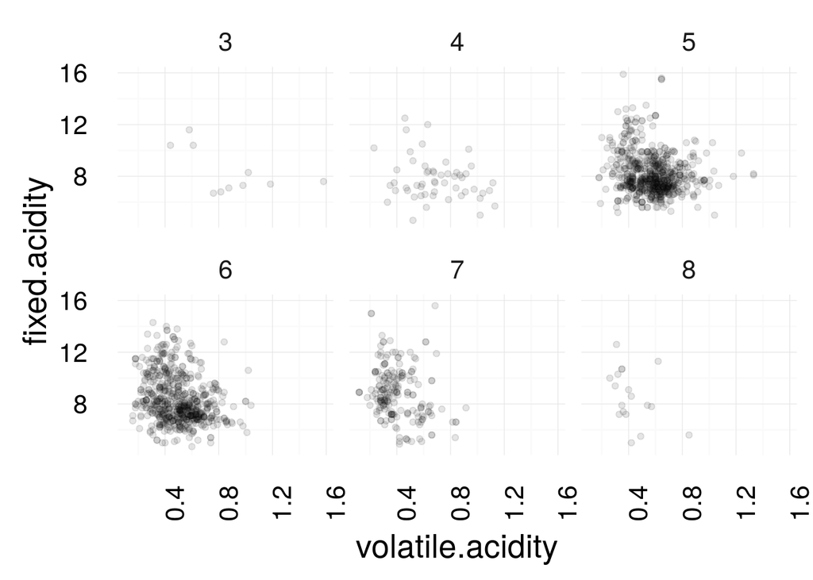

Looking at the graphs it looks like higher quality wine have lesser volatile acidity and the spread of fixed acidity is grouped between 7 and 12

Now I will see the combined effect of volatile acidity and citric acid on quality. Both of them are related to the taste of wine so trying to find out what kind of taste makes better wine

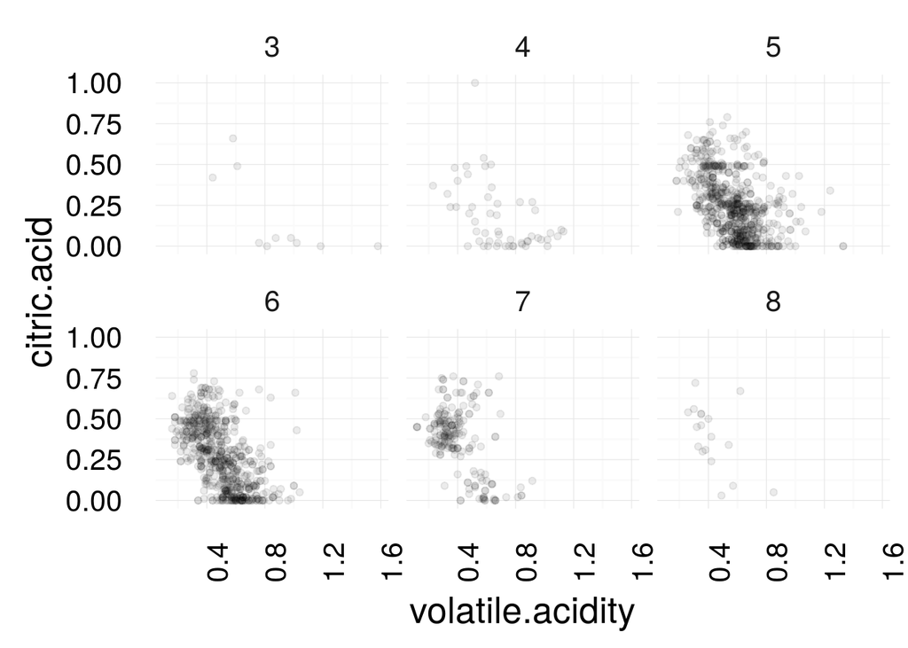

From this it looks like lower quality wine has more vinegar like taste and as th quality increases there seems to be 2 types of taste that seem to be good as seen by 2 seemingly different groups of points most apparent in quality of wine with rating 7 but also slightly prominent in quality of wine with rating 6

So for good quality wine maybe we need one of citric acid and volatile acidity in medium quantity while other should be low or negligible but not both

I will explore the relationship of fixed.acidity and density on the basis of quality to see if I can see anything

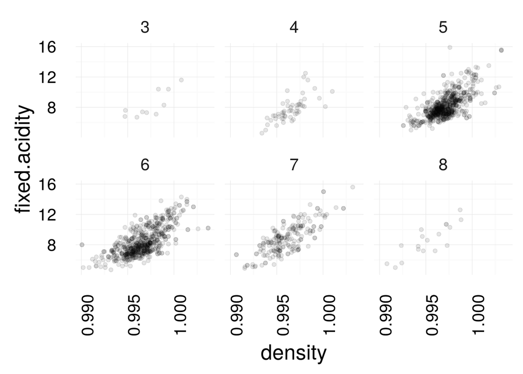

Looking at this nothing actionable seems to come out.

Let me try citric acid and residual sugar. Both of them change taste

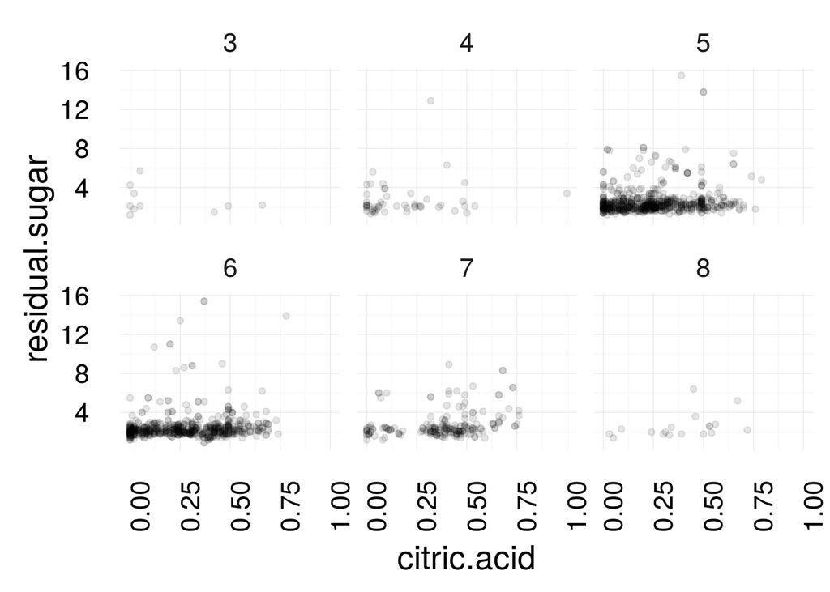

Again looking at this nothing actionable seems to come out.

Let me try citric acid and free sulphur dioxide. They say older wine is better. I wonder how the components that add freshness and prevent microbial growth affect the quality

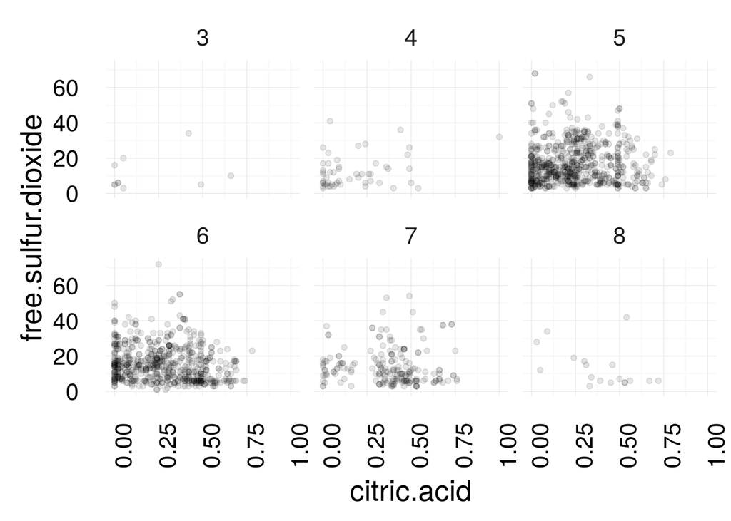

There doesn’t seem to anything interesting here

# Multivariate Analysis

### Talk about some of the relationships you observed in this part of the investigation. Were there features that strengthened each other in terms of looking at your feature(s) of interest?

- good quality wine seems to have one of citric acid and volatile acidity in medium quantity while other should be low or negligible but not both
- More acidic wine seems to have higher quality. Particularly acidity that does not evaporate matters. This was shown by positive correlation (0.124) of fixed.acidity and negative correlation (-0.391) of volatile.acidity. The pH didn’t really matter as shown by the very small correlation (-0.0507) as these two components affected the quality in opposite directions and thus overall acidity did not matter

### Were there any interesting or surprising interactions between features?

citric.acid and fixed.acidity seem to have a quadratic relationship between them

# Final Plots and Summary

### Plot One

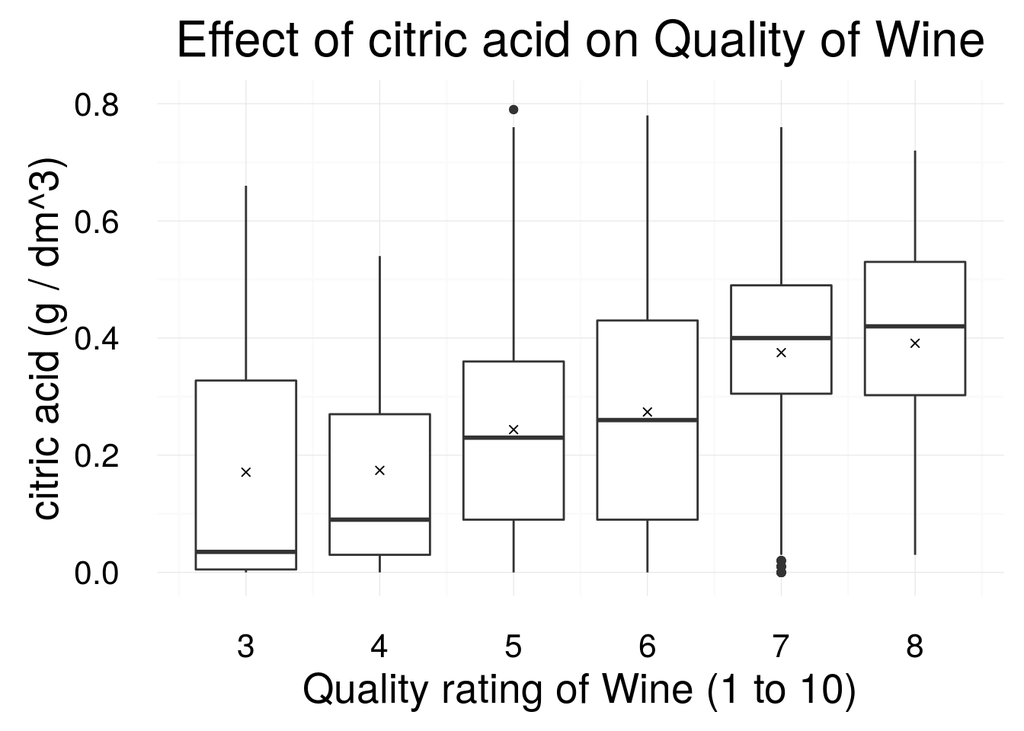

### Description One

This plot shows relationship between citric acid and quality of wine. It struck me as the correlation was clear to the eyes. Higher quality wine had higher citric acid on an average

### Plot Two

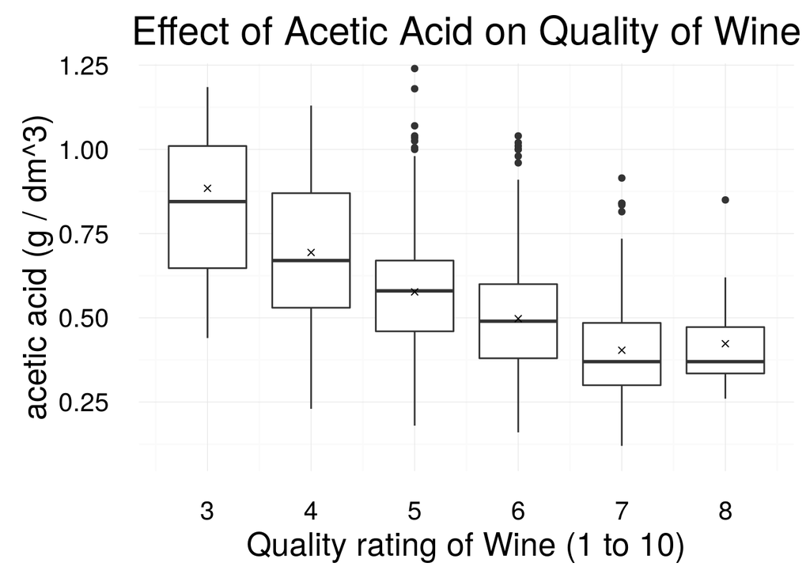

### Description Two

This plot shows relationship between acetic acid and quality of wine. It struck me as the correlation was clear to the eyes. Higher quality wine had lower acetic acid on an average

### Plot Three

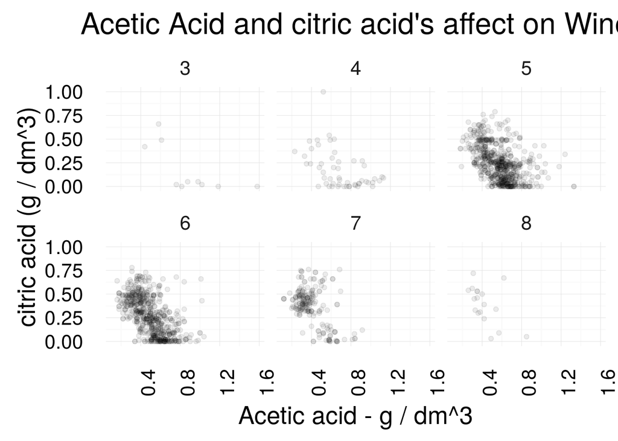

### Description Three

Struck me as good quality wine seems to have one of citric acid and acetic acid in medium quantity while other should be low or negligible

# Reflection

While doing this project I looked at single variable’s distributions. Not much came out of them. Nothing useful except that most of them were just normal. I was thinking I wasn’t going to get anything out of this dataset.

But when I used the bivariate analysis some insights about the correlation came out that can be very interesting. Looking at the various plots and correlations I drew the following general conclusions

- More acidic wine seems to have higher quality. Particularly acidity that does not evaporate matters. This was shown by positive correlation (0.124) of fixed.acidity and negative correlation (-0.391) of volatile.acidity. The pH didn’t really matter as shown by the very small correlation (-0.0507) as these two components affected the quality in opposite directions and thus overall acidity did not matter. Based on this if I want to take this exploration further and need to build a model I will consider the following while choosing features for my model
  - more alcohol means better wine
  - acidity that stays matters. citric.acid seems to help this a lot while sulphates do minor contributions

But the multivariate analysis was a challenge. Was not really sure what kind of relationships I could explore. The ggpairs plot prepared before helped me get some direction but not too much. So the multi variate analysis seemed too weak. To improve that I could go and check the original paper that did this wine analysis as suggested somewhere in the Udacity forums to see whether there are no relationships or did I just not have enough imagination but that would be against the Honour code so will do that after the project is finalized.